# Data Science Intern Case Study

## Nilüfer Çetin - 06.05.2021

This is file encompasses the questions and answers to the Data Science Case Study prepared by an e-commerce analytics company.

```python
import pandas as pd
import numpy as np
import matplotlib.pyplot as plt
import seaborn as sns
from random import randint
from sklearn import tree
from sklearn.model_selection import train_test_split
from sklearn.ensemble import RandomForestClassifier
from sklearn.metrics import accuracy_score
import xgboost as xgb
from xgboost import plot_tree
from google.colab import files
import warnings
warnings.filterwarnings('ignore')
```

```python
import io
uploaded = files.upload()
```

Upload widget is only available when the cell has been executed in the current browser session. Please rerun this cell to enable.

```
Saving data1.csv to data1 (1).csv
Saving data2.xlsx to data2 (1).xlsx
```

## Machine Learning Skills

The data for this set of questions is data1.csv. After it is gathered *duplicate* and *NA values*, if existing, should be dropped.

### Data Collection and Basic Manipulations

```python
data1 = pd.read_csv(io.StringIO(uploaded['data1.csv'].decode('utf-8')), delimiter=';', decimal=",")
print(data1)
```

```
      account length  location code  ...  customer service calls churn
0                128            415  ...                       1     0
1                107            415  ...                       1     0
2                137            415  ...                       0     0
3                 84            408  ...                       2     0
4                 75            415  ...                       3     0
...              ...            ...  ...                     ...   ...
3328             192            415  ...                       2     0
3329              68            415  ...                       3     0
3330              28            510  ...                       2     0
3331             184            510  ...                       2     0
3332              74            415  ...                       0     0

[3333 rows x 20 columns]
```

```python
data1 = data1.drop_duplicates(keep = 'first')
data1 = data1.dropna()
```

It is useful to check the **data types** of columns in the dataset for future manipulations and compatibility with visualization as well as machine learning algorithms,

```python
data1.dtypes
```

```
account length                           int64
location code                            int64
user id                                  int64
credit card info save                   object
push status                             object
add to wishlist                          int64
desktop sessions                         int64
app sessions                             int64
desktop transactions                     int64
total product detail views               int64
session duration                         int64
promotion clicks                         int64
avg order value                        float64
sale product views                       int64
discount rate per visited products     float64
product detail view per app session    float64
app transactions                         int64
add to cart per session                float64
customer service calls                   int64
churn                                    int64
dtype: object
```

It can be seen that the columns of **credit card info save** and **push status** is of type object and there are values of *yes* or *no* on these columns. For future use, these values are mapped into **1** for *yes* and **0** for *no*.

```python
data1['credit card info save'] = data1['credit card info save'].map(dict(yes=1, no=0))
data1['push status'] = data1['push status'].map(dict(yes=1, no=0))
```

### 1

Perform **Explanatory Data Analysis** on the dataset. Extract various insights from data by visualizing via different and suitable charts. Also explain the data-set verbally.

This data-set is actually consisting of several observations for *3333* customers of a bank. The first *19* columns are informations related to customers' experience with bank and usage of bank products, properties, cards, applications etc. The last column called *churn* is an indicator variable whether the customer have had left the bank in a specified time period unknown to the researcher. The columns can be briefly explained as,

**account length:** for how many months does the customer have the account, an integer nominal variable

**location code:** code of the location of the customer on bank records, a categorical variable

**user id:** customer's special number on bank records, a categorical variable with *3333* different categories

**credit card info save:** whether if customer has had their cards information saved in an application/web-page, a binary indicator variable

**push status:** whether if customer has allowed the bank to send notifications, a binary indicator variable

**add to wishlist:** number of items/products added by the customer to the wishlist, an integer nominal variable

**desktop sessions:** number of sessions in bank account opened on computer by customer, an integer nominal variable

**app sessions:** number of sessions in bank account opened on mobile application by customer, an integer nominal variable

**desktop transactions:** number of money transactions performed by the customer on computer, an integer nominal variable

**total product detail reviews:** number of times customer reviewed a product or service offered, an integer nominal variable

**session duration:** total or average time spent by the customer on web and mobile applications of bank, an integer nominal variable

**promotion clicks:** number of times the customer have been interested and clicked on a promotion offer, an integer nominal variable

**avg order value:** average cost/price of shopping made by the customer, an continuous nominal variable

**sale product views:** number of times customer reviewed a product or service that is on sale, an integer nominal variable

**discount rate per visited products:** average discount rates of the products the moment the customer visited, a continuous nominal variable

**product detail view per app session:** ratio of number product detail views to number of application sessions of customer, a continuous nominal variable

**app transactions:** number of money transactions performed by the customer on mobile application, an integer nominal variable

**add to cart per session:** how many things are added to card by the customer on average each session, a continuous nominal variable

**customer service calls:** how many times has the customer called the service, an integer nominal variable

**churn:** the indicator variable of whether the customer has left the bank

It is also useful to see how many different location codes exist in the dataset.

```python
pd.unique(data1['location code']) #3
```

```
array([415, 408, 510])
```

A small summary of the set can be demonstrated via,

```python
data1.describe()
```

|  | account length | location code | user id | credit card info save | push status | add to wishlist | desktop sessions | app sessions | desktop transactions | total product detail views | session duration | promotion clicks | avg order value | sale product views | discount rate per visited products | product detail view per app session | app transactions | add to cart per session | customer service calls | churn |
| --- | --- | --- | --- | --- | --- | --- | --- | --- | --- | --- | --- | --- | --- | --- | --- | --- | --- | --- | --- | --- |
| count | 3333.000000 | 3333.000000 | 3.333000e+03 | 3333.000000 | 3333.000000 | 3333.000000 | 3333.000000 | 3333.000000 | 3333.000000 | 3333.000000 | 3333.000000 | 3333.000000 | 3333.000000 | 3333.000000 | 3333.000000 | 3333.000000 | 3333.000000 | 3333.000000 | 3333.000000 | 3333.000000 |
| mean | 101.064806 | 437.182418 | 3.746291e+06 | 0.096910 | 0.276628 | 8.099010 | 179.811881 | 30.567957 | 17.087609 | 100.435644 | 201.039604 | 100.110711 | 200.872037 | 100.107711 | 9.039325 | 10.237294 | 4.479448 | 2.764581 | 1.562856 | 0.144914 |
| std | 39.822106 | 42.371290 | 2.746626e+05 | 0.295879 | 0.447398 | 13.688365 | 54.457135 | 9.269376 | 4.323795 | 20.069084 | 50.714359 | 19.923911 | 50.573847 | 19.568609 | 2.275873 | 2.791840 | 2.461214 | 0.753773 | 1.315491 | 0.352067 |
| min | 1.000000 | 408.000000 | 3.271058e+06 | 0.000000 | 0.000000 | 0.000000 | 0.000000 | 0.000000 | 0.000000 | 0.000000 | 0.000000 | 0.000000 | 23.200000 | 33.000000 | 1.040000 | 0.000000 | 0.000000 | 0.000000 | 0.000000 | 0.000000 |
| 25% | 74.000000 | 408.000000 | 3.508680e+06 | 0.000000 | 0.000000 | 0.000000 | 144.000000 | 24.000000 | 14.000000 | 87.000000 | 167.000000 | 87.000000 | 167.000000 | 87.000000 | 7.520000 | 8.500000 | 3.000000 | 2.300000 | 1.000000 | 0.000000 |
| 50% | 101.000000 | 415.000000 | 3.748187e+06 | 0.000000 | 0.000000 | 0.000000 | 179.000000 | 31.000000 | 17.000000 | 101.000000 | 201.000000 | 100.000000 | 201.200000 | 100.000000 | 9.050000 | 10.300000 | 4.000000 | 2.780000 | 1.000000 | 0.000000 |
| 75% | 127.000000 | 510.000000 | 3.985970e+06 | 0.000000 | 1.000000 | 20.000000 | 216.000000 | 37.000000 | 20.000000 | 114.000000 | 235.000000 | 114.000000 | 235.300000 | 113.000000 | 10.590000 | 12.100000 | 6.000000 | 3.270000 | 2.000000 | 0.000000 |
| max | 243.000000 | 510.000000 | 4.229964e+06 | 1.000000 | 1.000000 | 51.000000 | 351.000000 | 60.000000 | 31.000000 | 165.000000 | 364.000000 | 170.000000 | 395.000000 | 175.000000 | 17.770000 | 20.000000 | 20.000000 | 5.400000 | 9.000000 | 1.000000 |

As a first step, for the numerical variables histograms can be visualized,

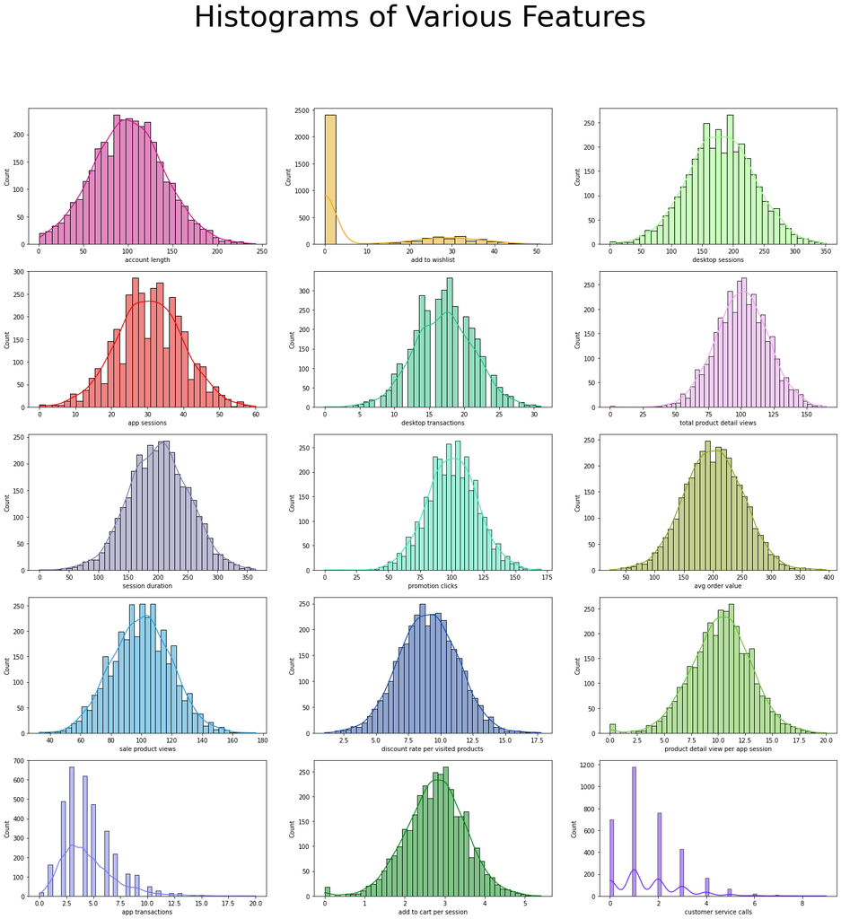

```python
selected_cols = [0]
colors = ['mediumvioletred']
for i in range(15):
    selected_cols.append(i+5)
    colors.append('#%06X' % randint(0, 0xFFFFFF))

fig, axes = plt.subplots(5,3, figsize=(24,24))
fig.suptitle("Histograms of Various Features", size=48)
for i in range(5):
    for j in range(3):
        sns.histplot(data1.iloc[:,selected_cols[3*i+j]], ax=axes[i,j], color=colors[3*i+j], kde=True)
```

It can be seen that most of the variables are distributed roughly normally which is a fair assumption for learning tasks. Nevertheless there are some interesting behavior with 'add to wish list', 'app transactions' and 'customer service calls'

It is shown that most people do not add anything to their wishlist, either they do not know the feature or not find it useful. Other people use the feature frequently on the contrary as, there is actually an approximate normal distribution with mean 30 and +-20 tails.

App transactions is an integer variable with highly clustered bins. Moreover, the distribution is not near normal bu more like Erlang with small k. It can also be interpreted as a normal distribution that is right skewed where median can be a better indicator of general tendency compared to the mean because of outliers on a small range.

Customer service calls show a similar behaviour too. It can be said that on average customers call service 1 or 2 times. But there are outlier values. Also this variable is highly clustered over a short number of integer values. It can be argued that this attribute can also be taken as categorical. Nevertheless, it is very probable that increase, decrease or a certain limit in the number of service calls might mean something for the target variable. Hence, the nominality of the variable will be preserved.

The groups in desktop transactions are also somewhat discrete demonstrating an interesting behavior. Also, there is a slight increase in the value of *0* for product detail view per app session and add to cart per session. This might also mean that some customers either they do not know the these features or not find them to be of use.

Also for categorical variables count of categories can be shown,

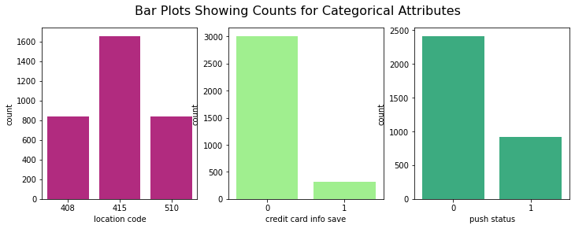

```python
nums = [1,3,4]
fig, axes = plt.subplots(1,3,figsize=(12,4))
plt.suptitle("Bar Plots Showing Counts for Categorical Attributes", size=16)
for i in range(3):
    sns.countplot(data1.iloc[:,nums[i]], ax = axes[i], color=colors[2*i])
```

A similar explanation can be done with box plots,

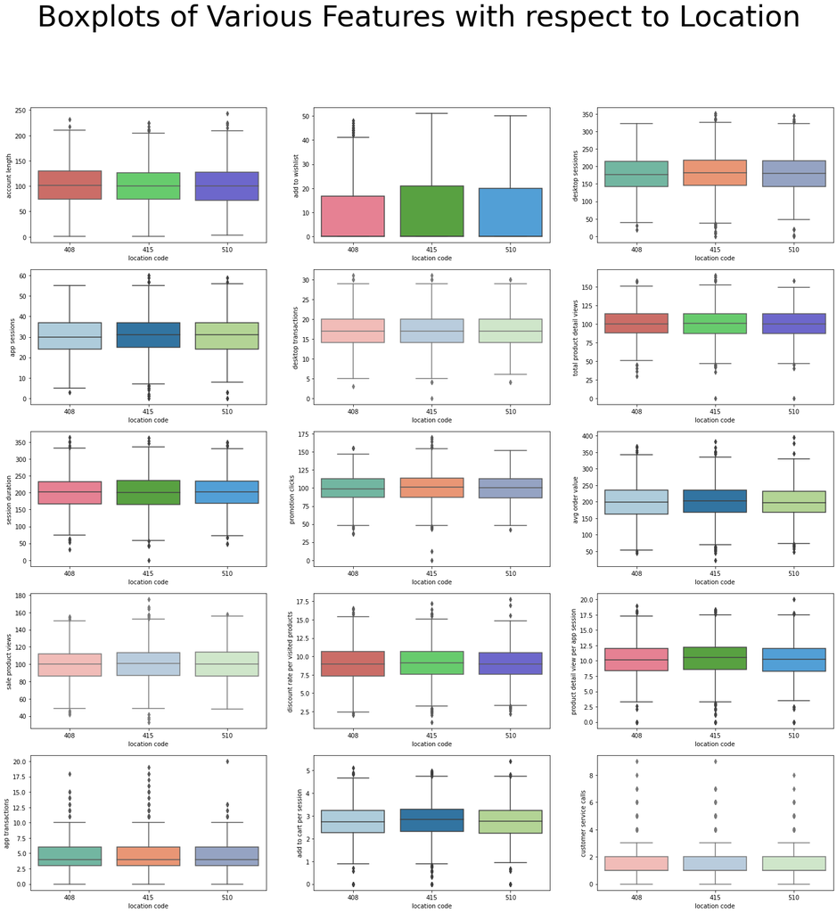

```python
pals = ['hls', 'husl', 'Set2', 'Paired', 'Pastel1']

fig, axes = plt.subplots(5,3, figsize=(24,24))
fig.suptitle("Boxplots of Various Features with respect to Location", size=48)
for i in range(5):
    for j in range(3):
        sns.boxplot(x=data1['location code'], y=data1.iloc[:,selected_cols[3*i+j]], ax=axes[i,j], palette=pals[(3*i+j)%5])
```

It is obvious that **location** does not lead to any different behaviours in the customers. The boxplots are the same of each other for every variable. Furthermore, mean values and outlier attributes can easily be seen.

Account lengths are more or less the same with small number of outliers and a mean value around 100.

It can be commented that customers from location 408 is using add to wishlist feature slightly less than other locations.

Desktop session mean is 175, app session mean is 30. Both attributes are a little less varied in location 408 comparably.

Average values for desktop transactions, total product views, session duration and promotion clicks are 17, 100, 200, 100. All are location-invariant.

Product detail view per app session is distributed the same everywhere with average 11, add to cart per session is nearly 3 for customers.

As mentioned before, there are many outliers for app transactions and service calls above the mean value.

For the same variables, it can be questioned whether the distribution changes for the "churn" customers. If splitted violin plots are visualized,

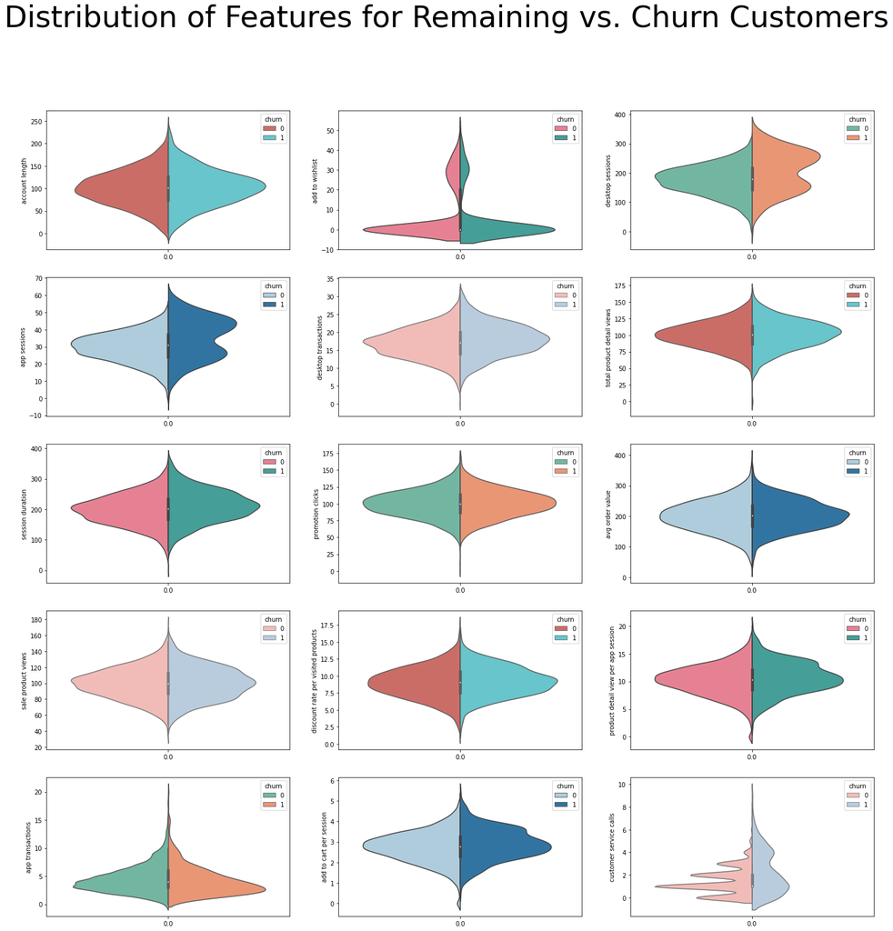

```python
colors = ['cornflowerblue']
for i in range(15):
    colors.append('#%06X' % randint(0, 0xFFFFFF))

fig, axes = plt.subplots(5,3, figsize=(24,24))
fig.suptitle("Distribution of Features for Remaining vs. Churn Customers", size=48)
for i in range(5):
    for j in range(3):
        sns.violinplot(x=np.zeros(3333), y =data1.iloc[:,selected_cols[3*i+j]], hue="churn",data=data1, ax=axes[i,j], split=True, palette=pals[(3*i+j)%5])
```

For most of the features, it can be seen that the distributions are the same with each other hinting that these features might not have much importance in understanding the reason behind the **churn** or predicting a model.

For desktop sessions and app sessions, same case is demonstrated. Though there are churn for all parameters, most of the churn are in two clusters with one's mean near the actual mean of the variable and other cluster's mean on a higher value. This reveals that though app sessions or desktop sessions are not the single driver of the churn, being above some threshold in these variables might increase the possiblity of churn.

Product detail view per app session and add to cart per session show a somewhat similar characteristic. However, the analogy is weak as the second cluster may not be statistically significant on some level of comparison.

The most striking difference is in the customer service calls, while the normal (churn 0) customers are distributed very similar to the overall distribution of this variable, it can be examined that the distribution of churn customers are really different with wider distribution averaging 1-2 and a second distribution created on mean 4. This illustrates that the customer service calls of churn customers can come from any service call value or customers calling service more might tend to churn because their percentage in churn distribution seem to be higher than the one in the overall distribution.

For the three categorical variables, percentage of churn in each category is demonstrated on the below *3* graphs.

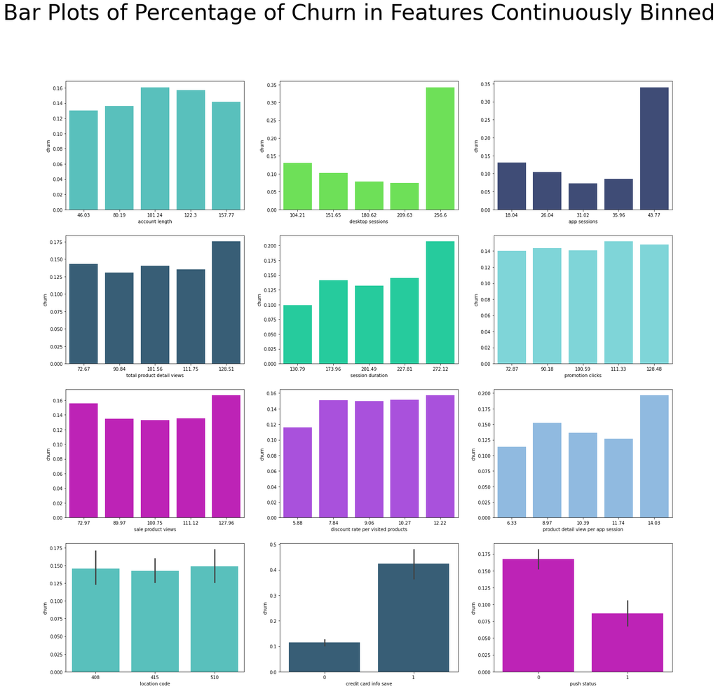

```python
selected_cols = [0]
colors = ['mediumturquoise']
for i in range(11):
    selected_cols.append(i+6)
    colors.append('#%06X' % randint(0, 0xFFFFFF))

categ = [1,3,4]

fig, axes = plt.subplots(4,3, figsize=(24,24))
fig.suptitle("Bar Plots of Percentage of Churn in Features Continuously Binned", size=48)
for i in range(3):
    for j in range(3):
        sub = data1.iloc[:,[selected_cols[4*i+j], 19]]
        sub['groups'] = pd.qcut(sub.iloc[:,0], 5, labels=["1", "2", "3", "4", "5"])
        sub = sub.groupby('groups').mean('churn')
        sns.barplot(x=np.round(sub.iloc[:,0],2), y=sub['churn'], color=colors[4*i+j], ax=axes[i,j])

for i in range(3):
    sns.barplot(x=data1.iloc[:,categ[i]], y=data1['churn'], color=colors[4*i], ax=axes[3,i])
```

For most variables, change in the level can not be associated with an increase in probability of churn.

As mentioned before, for the desktop sessions app sessions there is a boundary after which the churn rates increase significantly. Session duration and product detail view per app session show a like-wise case, but probabilities do not change that drastically. There are other small changes with the change in levels of some features but these are small and can be ignored.

The churn rates seem to be approximately same for locations. Saving the credit card info and not allowing for push notifications seem to be significant in increasing the churn probability for a customer.

Lastly, the correlations between columns can be demonstrated,

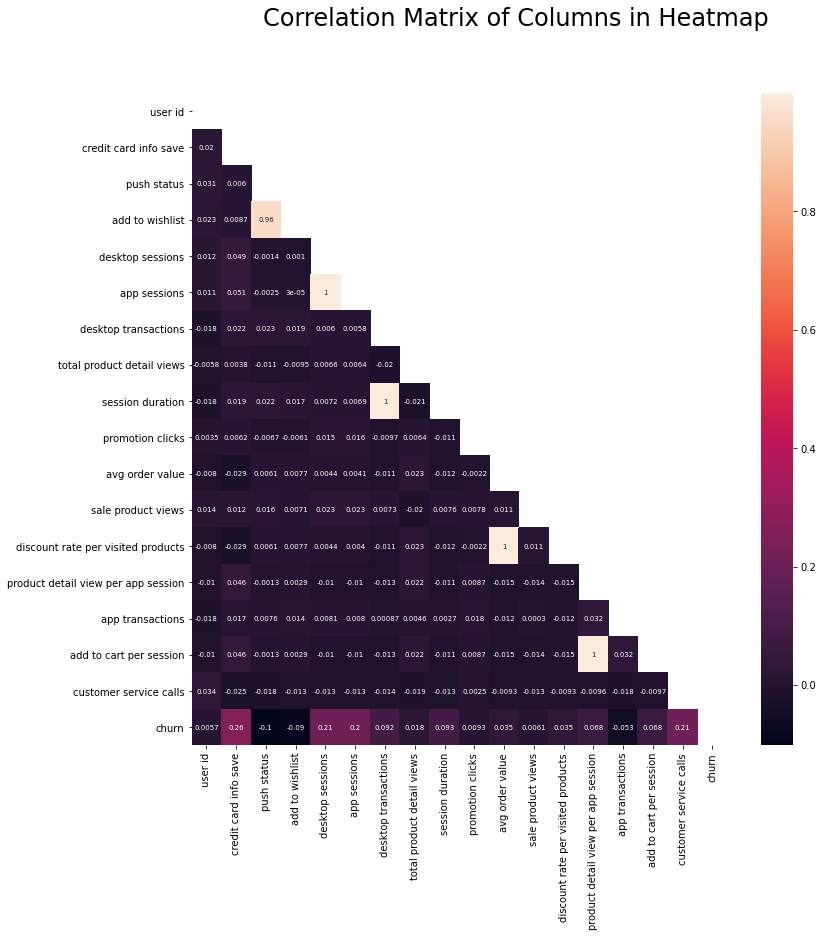

```python
mtr = data1.iloc[:,2:20].corr()
mask = np.zeros_like(mtr)
mask[np.triu_indices_from(mask)] = True
fig, ax = plt.subplots(figsize=(12,12))
plt.suptitle("Correlation Matrix of Columns in Heatmap", size=24)
sns.heatmap(mtr, mask= mask, annot=True, annot_kws={"size": 7})
```

The correlogram illustrates some strange patterns. For most of the variables there is no relationship in between.

On the other hand, add to wish list and push notifications seem to be almost perfectly positively correlated. Perhaps this is because items that are added to the wishlist are recognized by the customers usually when a notification is sent.

Also app and desktop sessions seem to be perfectly correlated. This actually explains the high extent of similarity in the features' behaviors with churn and location code as well as the similarity of distributions.

Discount rate per visited products is in perfect positive correlation with average order value. This can mean that customers tendency to buy products increase with discount rate.

Lastly, a similar association can be demonstrated between product detail per app session and add to cart per session, meaning that people tend to add the products they view more into the cart.

Interestingly, churn is weakly positively correlated with desktop and app sessions (they are the similar measures) and customer service calls. Moreover, as illustrated by the previous charts, there is weak positive association between saving credit card information and churn and weak negative association between allowing for push notifications and churn.

Normally after this step it would be meaningful to illustrate some bubble plots and show the churn using *3-dimensions* including size. However, the correlations are either non-existent or perfect. So, plotting bubble plots or scatter plots will not yield any useful information.

### 2

Perform **feature selection** before modelling the data.

It is obvious that the **user id** can not be an indicator of churn because it is specific to the customer and probably the IDs are not given by a rule related to age, gender, money, social class etc. Hence, **user id** column will be eliminated.

From the remaining features, although it seemed that the **location code** can be useful, it is seen via the detailed charts in the previous part that the location does not alter the distributions or change the rate of churn. This column will also be eliminated from the data. If this column were to be kept, then **one-hot encoding** would be needed.

From the visualizations in previous part, it is obvious that features such as desktop sessions, app sessions, credit card info save and push status can be important factors affecting churn rates. Also, product detail views, session duration, discount and sale product views seem to indicate change in percentage of churn at some levels, though weakly.

From the remaining features, the distribution for **desktop transactions** and **promotion clicks** are the same. Moreover, change in the **promotion click** amount do not seem to signal any change in churn behaviour from the barplot. It can be stated that these variables might not be of much importance in determination of churn. The distributions are also approximately the same for **avg order value** and this feature is moving with **discount rate per visited products**. Hence, keeping it in the model may not be necessary. These features also will not be selected.

The remaining features are kept and from feature selection *14* features are selected.

```python
features = pd.get_dummies(data1).drop(['user id', 'location code', 'desktop transactions', 'promotion clicks', 'avg order value'], axis=1)
feature_list = list(features.drop('churn', axis=1).columns)
features = features.to_numpy()
```

### 3

Create to models to fit and predict the **churn** variable with algorithms **random forest** and **xgboost**. Analyse the model via **variable importance module** and explain the most important features in model building by visualizing a bar chart.

Though a widely used methodology, **decision trees** are prone to **over-fitting** and usually the performance drops significantly in the testing stage. There are some parameters that can eliminate **over-fitting** to a certain degree such as keeping the depth of the tree small, not allowing for further seperations when a certain number of observations are present in the node (pre-prunning), not allowing for a node to split if at least one of the resultant nodes have a number of observations smaller than a specified threshold (post-prunning) and setting a necessary amount of the impurity before-hand.

Another possibility is to execute **cross-validation** to create a large tree and then **prunning** the large tree backwards. **Cross validation** is a methodology that is widely used for many statistical learning algorithms. It is preferred over **train-test** approach because of its allowance for changing the model at an early stage and using different batches of dataset to reduce **over-fitting**. Nevertheless, since the algorithms to be used are already **ensemble algorithms**, it is regarded enough by the researcher to use **train-test** approach.

### Random Forest

Random forest is an **ensemble** bagging algorithm that helps create several random trees with different feature selections and branching. The predictions are made via **majority voting** between the trees created.

For this part, *%20* of the data is seperated to be used in testing, while *%80* will be used in model building.

```python
X_train, X_test, Y_train, Y_test = train_test_split(features[:,:-1], features[:,-1:], test_size=0.2)
```

As the dataset is not very big, *5* trees are seen as enough for the forest. For each tree, to reduce the possiblity of over-fitting maximum depth is limited to *6* and it is not allowed for nodes to further seperate if they contain less than *20* observations.

```python
forest = RandomForestClassifier(n_estimators=5, max_depth=6, min_samples_split=20, random_state=4)
forest.fit(X_train, Y_train)
```

```
RandomForestClassifier(bootstrap=True, ccp_alpha=0.0, class_weight=None,
                       criterion='gini', max_depth=6, max_features='auto',
                       max_leaf_nodes=None, max_samples=None,
                       min_impurity_decrease=0.0, min_impurity_split=None,
                       min_samples_leaf=1, min_samples_split=20,
                       min_weight_fraction_leaf=0.0, n_estimators=5,
                       n_jobs=None, oob_score=False, random_state=4, verbose=0,
                       warm_start=False)
```

When this model is evalated on the test set, the accuracy is around *%90*.

```python
forest.score(X_test, Y_test)
```

```
0.9055472263868066
```

Feature importances can be visualized in a horizontal bar-plot,

```
<BarContainer object of 14 artists>
```

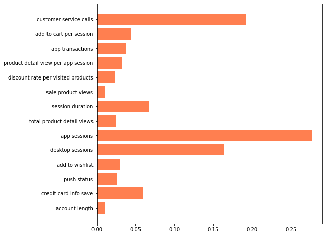

```python
fig, ax = plt.subplots(figsize=(8,8))
plt.barh(feature_list, forest.feature_importances_, color='coral')
```

Although random state is set for repeatability, in most of the cases the main features with highest importances are the same. As also revealed in the EDA process; **app sessions** and **desktop sessions** are both important for the model.

It has been observed in the violin-plots that the distribution of customer service calls changes drrastically for churn and non-churn customer populations, this drastic change is reflected in the importances of the random forest model as **customer service calls** are almost always the most or the second most important fearture in models.

**Credit card info save**, as shown by the barplots of percentage of churn in EDA has been an important determinant on predicting churn.

Moreover, **app transactions**, **session duration**, **product detail view per app session** and **discount rate per visited products** are features that usually come off as somewhat important in several models. It has been expected for **session duration**, **product detail view per app session** and **discount rate per visited products** to be important as barplots and splitted violinplots have hinted a change before. However, selection of **app transactions** has been surprising.

**Account length**, **sale product views** and **total product views** are usually features with too little importance. This might be an expected result as change in levels or being on a certain level do not change the percentage of churn in a statistically significant manner.

### XG Boost

XGBoost is an **ensemble** boosting algorithm that is named after **Gradient Boosting** and makes use of **learning rate** as well as **regularization while creating different trees. Although depending on tree structure and ensembling trees, XGBoost is built different compared to the random forest.

Nevertheless, there are some parameters that can be adjusted in **XGBoost** to make the probability of **over-fitting** decrease. Just like **random forest** maximum depth of the trees, number of the trees, learning rate, the objective function (in this case there is binary target variable) and the regularizer parameter alpha is given.

When the splitted data is used to train a **XGBoost model**,

```python
xg_cl = xgb.XGBClassifier(objective ='binary:logistic', colsample_bytree = 0.3, learning_rate = 0.1, max_depth = 5, alpha = 10, n_estimators = 4, random_state=4)
xg_cl.fit(X_train,Y_train)
```

```
XGBClassifier(alpha=10, base_score=0.5, booster='gbtree', colsample_bylevel=1,
              colsample_bynode=1, colsample_bytree=0.3, gamma=0,
              learning_rate=0.1, max_delta_step=0, max_depth=5,
              min_child_weight=1, missing=None, n_estimators=4, n_jobs=1,
              nthread=None, objective='binary:logistic', random_state=4,
              reg_alpha=0, reg_lambda=1, scale_pos_weight=1, seed=None,
              silent=None, subsample=1, verbosity=1)
```

```python
accuracy_score(Y_train, xg_cl.predict(X_train))
```

```
0.8975993998499625
```

When the feature importances are visualized,

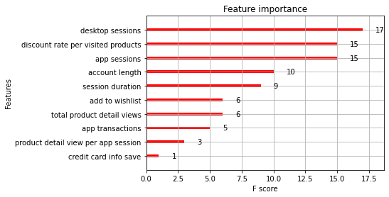

```python
xg_cl.get_booster().feature_names = feature_list
xgb.plot_importance(xg_cl.get_booster(), color='red')
```

Interestingly, the feature importances vary a lot from one instance to another compared to the experiments with **random forest**. This reveals an underlying difference between the two methodologies. In this case as the accuracy has been higher and the feature importances have been less variant, **random forest** is a safer option to build a model.

Another surprising result is that **account length** and **session duration** are usually more important in these models, decreasing the trust into modelling the dataset with this methodology because these variables have not seemed much important in EDA process.

### 4

Compare the models on *0.6* versus *0.8* train sizes for both models.

Since the models have already been built with *0.8* train size, the data has been splitted again with *0.6* train size,

```python
X_train1, X_test1, Y_train1, Y_test1 = train_test_split(features[:,:-1], features[:,-1:], test_size=0.4)
```

The model for **random forest** is created using the same parameters. When the model is evaluated on the test data,

```python
forest1 = RandomForestClassifier(n_estimators=5, max_depth=6, min_samples_split=20, random_state=4)
forest1.fit(X_train1, Y_train1)
forest1.score(X_test1, Y_test1)
```

```
0.9032983508245878
```

It can be seen that the accuracy in the test period is roughly the same. There is an increase that is very small and attaining the same level a good thing. When building some models, if the models are prone to **over-fitting** increase in the size of the training set increases the **generalization ability** of the model and hence decreases the **test period error rate**. If there were any over-fitting in the models, the classification accuracy of the model with larger training set (*0.8*) would have been significantly better than the classification accuracy of the model with smaller training set (*0.6*). It can be concluded that both models are useful with approximately same performance.

The model for **xg boost** is created using the same parameters. When the model is evaluated on the test data,

```python
xg_cl1 = xgb.XGBClassifier(objective ='binary:logistic', colsample_bytree = 0.3, learning_rate = 0.1, max_depth = 5, alpha = 10, n_estimators = 4, random_state=4)
xg_cl1.fit(X_train1,Y_train1)
accuracy_score(Y_train1, xg_cl1.predict(X_train1))
```

```
0.8979489744872436
```

### 5

Express the mathematical equation of the models or visualize models.

[figure not shown]

```python
fig, axes = plt.subplots(nrows = 1,ncols = 5,figsize = (10,2), dpi=900)

for i in range(5):
    tree.plot_tree(forest.estimators_[i],feature_names = feature_list, class_names='churn',filled = True, ax=axes[i]);
    axes[i].set_title('Estimator: ' + str(i+1), fontsize = 11)
```

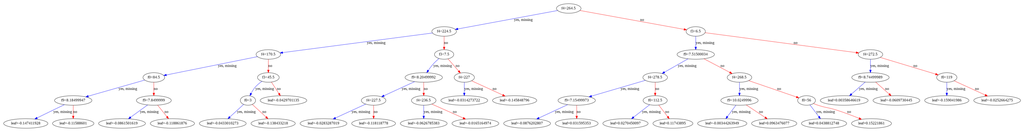

```python
fig, ax = plt.subplots(figsize=(48, 48))
plot_tree(xg_cl, num_trees=3, ax=ax)
```

## Python Skills

The data for this set of questions is **data2.csv**. The file contains different sheets and all sheets will be gathered. That is why keys are checked,

```python
data2 = pd.read_excel(io.BytesIO(uploaded.get('data2.xlsx')), sheet_name=None)
data2.keys()
```

```
dict_keys(['Public_Schools', 'School Type', 'Police', 'Company&Food Order'])
```

For any dataset, *duplicate* and *NA values* should be checked.

```python
data2['Public_Schools'] = data2['Public_Schools'].drop_duplicates(keep = 'first')
data2['Police'] = data2['Police'].drop_duplicates(keep = 'first')
data2['Company&Food Order'] = data2['Company&Food Order'].drop_duplicates(keep = 'first')

data2['Public_Schools'] = data2['Public_Schools'].dropna()
data2['Police'] = data2['Police'].dropna()
data2['Company&Food Order'] = data2['Company&Food Order'].dropna()
```

### 1

Create a list from the **city names** in **Public_Schools** data set.

Unique observations of **city names** can be gathered in a list by,

```python
list(pd.unique(data2['Public_Schools']['CITY']))
```

```
['East Boston',
 'Charlestown',
 'Boston',
 'Roxbury',
 'Dorchester',
 'South Boston',
 'West Roxbury',
 'Mattapan',
 'Roslindale',
 'Jamaica Plain',
 'Hyde Park',
 'Brighton',
 'Allston']
```

### 2

How many schools there are in **each** city?

By grouping the number of unique **school names** over the **city names**, an informative data frame can be created as,

```python
temp = data2['Public_Schools'].groupby('CITY')['SCH_NAME'].nunique().to_frame()
temp.rename(columns={'SCH_NAME' : '#Schools'})
```

| CITY | #Schools |
| --- | --- |
| Allston | 3 |
| Boston | 14 |
| Brighton | 7 |
| Charlestown | 4 |
| Dorchester | 27 |
| East Boston | 11 |
| Hyde Park | 7 |
| Jamaica Plain | 12 |
| Mattapan | 6 |
| Roslindale | 7 |
| Roxbury | 19 |
| South Boston | 6 |
| West Roxbury | 7 |

### 3

What is the **zip code** of the school named **Hennigan K-8**?

Over the Public_Schools dataset, if condition on SCH_NAME is given as 'Hennigan K-8' and then the zip code column is selected, this would give a filtered slice of a data-frame of one row and one column. To gather only the **zip code**, the type is casted to int by,

```python
int(data2['Public_Schools'][data2['Public_Schools']['SCH_NAME'] == 'Hennigan K-8']['ZIPCODE'])
```

```
2130
```

### 4

Perform a groupby operation in order to show **zip codes** in each **city**.

The data is grouped by the **city name**, then for each group, unique **zip codes** are extracted into a data frame via,

```python
temp = data2['Public_Schools'].groupby('CITY').apply(lambda x: x['ZIPCODE'].unique()).to_frame()
temp = temp.rename(columns={temp.columns[0] : 'ZipCodes'})
temp
```

| CITY | ZipCodes |
| --- | --- |
| Allston | [2134] |
| Boston | [2113, 2116, 2111, 2118, 2121, 2115, 2215] |
| Brighton | [2135] |
| Charlestown | [2129] |
| Dorchester | [2125, 2121, 2122, 2124] |
| East Boston | [2128] |
| Hyde Park | [2136] |
| Jamaica Plain | [2130, 2115] |
| Mattapan | [2126] |
| Roslindale | [2131] |
| Roxbury | [2119, 2118, 2120] |
| South Boston | [2127] |
| West Roxbury | [2132] |

### 5

How many **zip codes** are there in the city of **Boston**?

From the previous dataframe, the length of the observation with index **Boston** is found to be *7*.

```python
len(temp[temp.index == 'Boston']['ZipCodes'][0])
```

```
7
```

### 6

The **zip codes** in USA are normally 5-digits, why are these **zip codes** are 4-digits? Find an explanation and fix the codes accordingly.

For this question, an answer is checked first on the Kaggle page of the data-set. However, no relevant answers were found there as probably **zip code** is not a numeric attribute but rather a categorical one and missing *1* digit in all observations is not of much importance in analysis and model fitting. However, when an answer is searched on Google, it is revealed that the **zip codes** in Boston have a **leading zero**. This zero might have been probably lost in recording the data on some medium as the data type can easily be confused to be a numerical one. Hence, leading zeros are added to fill for the **fifth digit**,

```python
data2['Public_Schools']['ZIPCODE'] = data2['Public_Schools']['ZIPCODE'].apply(lambda x: str(x).zfill(5))
data2['Public_Schools']
```

|  | CITY | ZIPCODE | SCH_NAME | SCH_TYPE |
| --- | --- | --- | --- | --- |
| 0 | East Boston | 02128 | Guild Elementary | ES |
| 1 | East Boston | 02128 | Kennedy Patrick Elem | ES |
| 2 | East Boston | 02128 | Otis Elementary | ES |
| 3 | East Boston | 02128 | O'Donnell Elementary | ES |
| 4 | East Boston | 02128 | East Boston High | HS |
| ... | ... | ... | ... | ... |
| 126 | Roxbury | 02119 | Higginson Elementary (K1-2) | ES |
| 127 | East Boston | 02128 | Alighieri Montessori | ES |
| 128 | Boston | 02116 | Boston Adult Tech Acad | Special |
| 129 | Brighton | 02135 | Boston Green Academy | 2006-07-12 00:00:00 |
| 130 | Roxbury | 02119 | Dearborn Academy | 2006-07-12 00:00:00 |

130 rows × 4 columns

### 7

While in rows of **school type**, there are mostly school codes, on the last two lines of the data-set there seems a date format. Search why this is the case.

When the data set is taken from the original root at [Kaggle](https://www.kaggle.com/crawford/boston-public-schools?select=Public_Schools.csv), the **school codes** of these schools seem to be registered as **6-7/12**. Perhaps while recording the data to another excel or changing the file type, this column might have been accepted by *Excel* as a **date** type as **July 12th 2006**.

### 8

Print all correlations from **Police** dataset. Declare the type of correlation between the two variables with highest significance correlation and show this relation by a chart.

When correlations are found,

```python
data2['Police'].corr()
```

|  | Officers per 10k population | officers | Employees per 10K population | employees | Population |
| --- | --- | --- | --- | --- | --- |
| Officers per 10k population | 1.000000 | 0.489196 | 0.942033 | 0.477221 | 1.000000 |
| officers | 0.489196 | 1.000000 | 0.552765 | 0.999250 | 0.489196 |
| Employees per 10K population | 0.942033 | 0.552765 | 1.000000 | 0.550630 | 0.942033 |
| employees | 0.477221 | 0.999250 | 0.550630 | 1.000000 | 0.477221 |
| Population | 1.000000 | 0.489196 | 0.942033 | 0.477221 | 1.000000 |

It is very useful to use a **scatter plot** for such relationships of correlation between two variables,

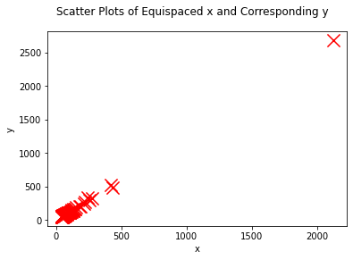

```python
fig, ax = plt.subplots()
fig.suptitle("Scatter Plots of Equispaced x and Corresponding y", size=12)
ax.set(ylabel='y', xlabel='x')
plt.scatter(data2['Police']['officers'],data2['Police']['employees'], marker='x', color='red', s=200)
```

Because of one outlier observation, the other observations have become clustered and dense which hid the actual visualization of the relation ship. The plot can be visualized with smaller x-y range and more widely to reduce density as,

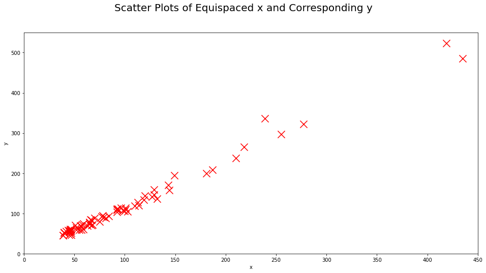

```python
fig, ax = plt.subplots(figsize=(16,8))
fig.suptitle("Scatter Plots of Equispaced x and Corresponding y", size=20)
ax.set_xlim(0,450)
ax.set_ylim(0,550)
ax.set(ylabel='y', xlabel='x')
plt.scatter(data2['Police']['officers'],data2['Police']['employees'], marker='x', color='red', s=200)
```

As can be seen, it is **almost** a perfect line with positive slope, indicating **strong positive linear relationship**.

### 9

Find the **most** in-demand food type in the data set of **Company&Food Order**. Sort **average prices** for all **food types** in **descending order**.

First, number of observations of each food type is brought into a data frame,

```python
temp = data2['Company&Food Order']['Food Type'].value_counts().to_frame()
temp
```

|  | Food Type |
| --- | --- |
| soups | 39 |
| cereals | 37 |
| desserts | 33 |
| stews | 31 |
| pasta | 30 |
| salads | 30 |
| sandwiches | 27 |
| seafood | 27 |
| pies | 26 |
| noodles | 20 |

Then the **index** of the observation with maximum count is found as,

```python
temp['Food Type'].idxmax()
```

```
'soups'
```

For **average prices**, the mean of **currency** is aggregated over **food types**. Then the gathered frame is sorted,

```python
temp = data2['Company&Food Order'].groupby('Food Type').mean('Currency')
temp.sort_values(by='Currency', ascending=False)
```

| Food Type | Currency |
| --- | --- |
| seafood | 57.213333 |
| stews | 56.108065 |
| cereals | 54.760000 |
| sandwiches | 54.358889 |
| noodles | 50.730500 |
| soups | 48.799744 |
| salads | 47.639667 |
| desserts | 45.292727 |
| pies | 45.037692 |
| pasta | 44.993667 |

## Algorithm Skills

There are two questions in this set.

### 1

Find an algorithm that finds the **smallest** of three numbers given as inputs.

Basically, if a number is not smaller than both of the others at the same time, then there are two candidates left being the smallest. If these candidates are compared with each other, the minimum input is found.

```python
def minimum():
    num1 = float(input())
    print("First input taken as", num1)
    num2 = float(input())
    print("Second input taken as", num2)
    num3 = float(input())
    print("Last input taken as", num3)
    print("Smallest number is ")
    if num1 <= num2 and num1 <= num3:
        print(str(num1))
    elif num2 <= num3:
        print(str(num2))
    else:
        print(str(num3))
```

```python
minimum()
```

```
138392
First input taken as 138392.0
38.2
Second input taken as 38.2
62.54556
Last input taken as 62.54556
Smallest number is
38.2
```

### 2

For both tasks, counting number of **vowels** for a given string is required. A function is created to help purpose that ignores the lower-upper.

```python
def vowel(word):
    count = 0
    for i in list(word.lower()):
        if i in list(('a', 'e', 'i', 'u', 'o')):
            count += 1
    return count
```

Both tasks also require iterating over the data and calculating the number of vowels for each city name. So a data-frame is created beforehand.

```python
vowels = pd.DataFrame(np.unique(data2['Police']['City']), columns=['City'])
vowels['Vowels'] = np.zeros(len(vowels))
vowels
```

|  | City | Vowels |
| --- | --- | --- |
| 0 | Agawam, Massachusetts | 0.0 |
| 1 | Andover, Massachusetts | 0.0 |
| 2 | Arlington, Massachusetts | 0.0 |
| 3 | Attleboro, Massachusetts | 0.0 |
| 4 | Barnstable, Massachusetts | 0.0 |
| ... | ... | ... |
| 70 | West Springfield, Massachusetts | 0.0 |
| 71 | Westfield, Massachusetts | 0.0 |
| 72 | Weymouth, Massachusetts | 0.0 |
| 73 | Woburn, Massachusetts | 0.0 |
| 74 | Worcester, Massachusetts | 0.0 |

75 rows × 2 columns

Iterating over **city names**, each cell is filled and maximum vowels are found in,

```python
highest = 0
index = 0
for i in range(0, len(vowels)):
    city_vowels = vowel(vowels['City'][i])
    vowels['Vowels'][i] = city_vowels/len(vowels['City'][i])
    if city_vowels > highest:
        highest = city_vowels
        index = i
print(highest)
print("Most vowels are in -> ", str(vowels['City'][index]), " With: ", str(highest))
```

```
9
Most vowels are in ->  North Attleboro, Massachusetts  With:  9
```

The data-frame is,

```python
vowels
```

|  | City | Vowels |
| --- | --- | --- |
| 0 | Agawam, Massachusetts | 0.333333 |
| 1 | Andover, Massachusetts | 0.318182 |
| 2 | Arlington, Massachusetts | 0.291667 |
| 3 | Attleboro, Massachusetts | 0.333333 |
| 4 | Barnstable, Massachusetts | 0.280000 |
| ... | ... | ... |
| 70 | West Springfield, Massachusetts | 0.258065 |
| 71 | Westfield, Massachusetts | 0.291667 |
| 72 | Weymouth, Massachusetts | 0.304348 |
| 73 | Woburn, Massachusetts | 0.285714 |
| 74 | Worcester, Massachusetts | 0.291667 |

75 rows × 2 columns

## Social Science Skills

Name *5* variables that might affect the demand in the products of an e-commerce company with reasons. (ex. 'Price')

1. **Price**

Not only in e-commerce setting but in all free-markets with competition, price is important. People have a marginal boundary for each product and service based on most factors such as their needs, personalities, wealth and socio-economic status. A price that is above the boundary for a product, will eventually decrease the demand in the product.

On the other hand, cheaper products might attract more people but there are also another constraints for the company to operate with profit because of costs of production.

1. **Seasonality**

Not all, but demand for some products can change drastically or slightly through seasons. Best examples are; sun-glasses, air coolers, scarves, iced-tea and boots. The seasonality does not always need to refer to a specific season, sometimes a special day, holiday, week or festival can also affect the demand for a product.

Such as the increase in demand for flowers around Mothers Day and Valentines Day or more bicycles bought at the beginning of school holidays. Nevertheless, this is also not only the case for e-commerce companies.

1. **Special Events and Campaigns**

Announcing a decrease in the price is usually a demand-increaser because it will signal a **profitable exchange** for people even if the price is still high for the product. Many companies but mostly the e-commerce giants, use such strategies like **Mega Discount Days** or **Ultra Surprise Discount Week** for several categories of products to increase the demand. Which actually lead people to postpone their shoppings till the event or create a non-existent demand because of the perception and in turn **increase** the demand.

This is also suitable for non-e-commerce companies but mostly used in e-commerce. Moreover, its interaction with the price and seasonality is also worth inspecting.

1. **Layout, Ease of Use and Interface of the Website**

E-commerce means shopping online. This encompasses not only the process of placing an order but also searching for the most suitable, useful, profitable or satisfying product. Web-pages with disturbing layout, complicated design or hard to use interface might be repulsive to look at or even to use. Another important factor is the amount of information provided and the accesibility of the information. Web-sites or applications with too little information or showing too many information at once might be uncomfortable to search and shop at.

1. **Cargo Company and Arrival Statistics of Orders**

Searching for the best alternative and placing the order is not the end of the shopping. Lead time of arrival and the status of product arriving the customer is also very important. Cargo shipment companies are thought of as very problematic in Turkey and there are only small amount of people which have never encountered a problem with the delivery company or person. Hence, the choice with the company or, the satisfaction with the delivery system of the company if it has its own can be an important factor in determining the place to shop on e-commerce.

Other important factors can be **quality of the products sold**, **variability of the products or services offered**, **competition level of the market of operation**, **past customer satisfaction rate**, **accessibility of product reviews, comments by the customer**.

## Appendices

The following web-pages and forums are throughly used in preparation of this file,

[Stack Over Flow](https://stackoverflow.com/)

[Machine Learning Mastery](https://machinelearningmastery.com/)

[Python Graph Gallery](https://www.python-graph-gallery.com/)

[Data Camp](https://www.datacamp.com/)

[Towards Data Science](https://towardsdatascience.com/)

[Stack Exchange](https://stackexchange.com/)

[Medium](https://medium.com/)

[Machine Learning Jar](https://mljar.com/)

[SciKit Learn Documentation](https://scikit-learn.org/stable/index.html)

[MatPlotLib Documentation](https://matplotlib.org/stable/index.html)

[Seaborn Documentation](https://seaborn.pydata.org/index.html)

[Pandas Documentation](https://mljar.com/)

[Kaggle](https://www.kaggle.com/)

[Introduction to Machine Learning with Python Book](https://www.oreilly.com/library/view/introduction-to-machine/9781449369880/)